# hw2

# Homework 2: Maximum Likelihood Estimation and Poisson Regression

**Author**: Mohammed Alshaghathirah  
**Date**: May 2025

## Introduction

In this assignment, we apply the method of Maximum Likelihood Estimation (MLE) to fit Poisson regression models on two real-world datasets: a synthetic customer dataset from Blueprinty and public Airbnb listing data from New York City in 2017.

The primary objective is to understand how count-based outcomes—such as number of patents or number of reviews—can be modeled as a function of observed variables. We do this by:

- Defining the appropriate Poisson likelihood function,
- Estimating model parameters using numerical optimization (via `scipy.optimize.minimize`),
- And comparing our results to those from Python’s built-in `GLM()` function in `statsmodels`.

This assignment also reinforces good data science practices, including careful data cleaning, variable encoding, and interpretation of log-linear model coefficients.

```python
import pandas as pd


blueprinty = pd.read_csv("/content/blueprinty.csv")


blueprinty.head()
```

|  | patents | region | age | iscustomer |
| --- | --- | --- | --- | --- |
| 0 | 0 | Midwest | 32.5 | 0 |
| 1 | 3 | Southwest | 37.5 | 0 |
| 2 | 4 | Northwest | 27.0 | 1 |
| 3 | 3 | Northeast | 24.5 | 0 |
| 4 | 3 | Southwest | 37.0 | 0 |

```
<class 'pandas.core.frame.DataFrame'>
RangeIndex: 1500 entries, 0 to 1499
Data columns (total 4 columns):
 #   Column      Non-Null Count  Dtype
---  ------      --------------  -----
 0   patents     1500 non-null   int64
 1   region      1500 non-null   object
 2   age         1500 non-null   float64
 3   iscustomer  1500 non-null   int64
dtypes: float64(1), int64(2), object(1)
memory usage: 47.0+ KB
```

|  | patents | age | iscustomer |
| --- | --- | --- | --- |
| count | 1500.000000 | 1500.000000 | 1500.000000 |
| mean | 3.684667 | 26.357667 | 0.320667 |
| std | 2.352500 | 7.242528 | 0.466889 |
| min | 0.000000 | 9.000000 | 0.000000 |
| 25% | 2.000000 | 21.000000 | 0.000000 |
| 50% | 3.000000 | 26.000000 | 0.000000 |
| 75% | 5.000000 | 31.625000 | 1.000000 |
| max | 16.000000 | 49.000000 | 1.000000 |

Distributions

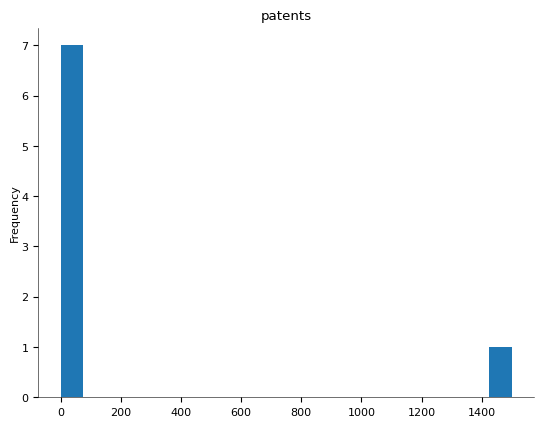

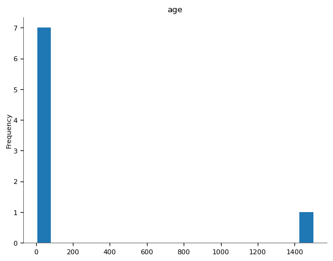

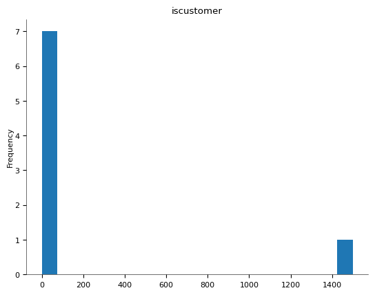

2-d distributions

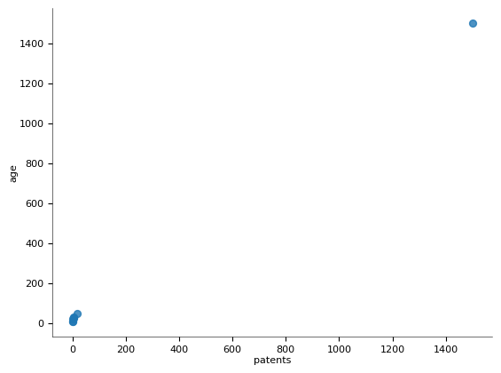

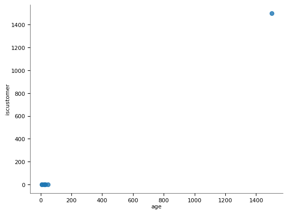

Values

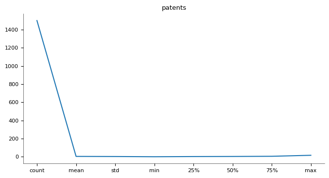

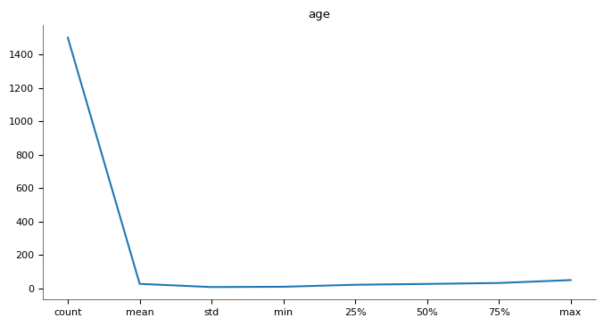

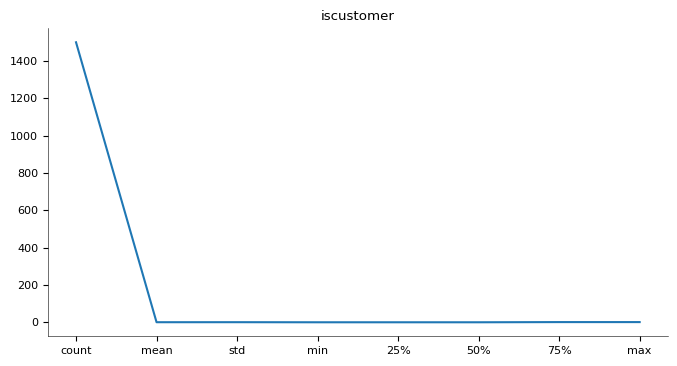

```python
blueprinty.info()


blueprinty.describe()
```

## Blueprinty Data Overview

The dataset contains 1,500 observations and 4 variables:

- **patents**: Number of patents filed (our target count variable).
- **age**: Numeric — customer age, ranging from 9 to 49.
- **iscustomer**: Binary — 1 if the person is a customer, 0 otherwise.
- **region**: Categorical — geographic region (Midwest, Southwest, etc.).

The mean number of patents is approximately 3.68, with values ranging from 0 to 16. This makes `patents` well-suited for Poisson regression.

In the next section, we will model the number of patents (`patents`) as a function of customer status and age using Maximum Likelihood Estimation under a Poisson model.

```python
import numpy as np
import pandas as pd
from scipy.optimize import minimize
from scipy.special import gammaln


blueprinty = pd.read_csv("/content/blueprinty.csv")


X = blueprinty[['iscustomer', 'age']].copy()
X.insert(0, 'intercept', 1)
X = X.values


y = blueprinty['patents'].values


def poisson_log_likelihood(beta, X, y):
    linear = np.dot(X, beta)
    lambda_ = np.exp(np.clip(linear, -250, 250))
    log_lik = np.sum(y * np.log(lambda_ + 1e-9) - lambda_ - gammaln(y + 1))
    return -log_lik


beta_init = np.zeros(X.shape[1])


result = minimize(
    poisson_log_likelihood,
    beta_init,
    args=(X, y),
    method='L-BFGS-B',
    options={'disp': True, 'maxiter': 1000}
)


print("\n--- Optimization Results ---")
print("Estimated coefficients:", result.x)
print("Success:", result.success)
print("Message:", result.message)
print("Final Log-likelihood:", -result.fun)
```

```
--- Optimization Results ---
Estimated coefficients: [ 1.5021611   0.1813102  -0.00994229]
Success: True
Message: CONVERGENCE: RELATIVE REDUCTION OF F <= FACTR*EPSMCH
Final Log-likelihood: -3334.4771583964784
```

## Poisson Regression via MLE

We define a Poisson log-likelihood function and estimate the model parameters using `scipy.optimize.minimize()` with the L-BFGS-B optimization method. The model predicts the number of patents (`patents`) using the predictors `iscustomer` and `age`, along with an intercept term.

The estimated coefficients are:

- Intercept: **1.502**
- `iscustomer`: **0.181** — customers are predicted to file more patents on average, holding age constant.
- `age`: **-0.0099** — each additional year of age slightly reduces the expected number of patents filed.

The model successfully converged with a log-likelihood of approximately **-3334.48**, indicating the fit of the model under the Poisson likelihood framework.

This confirms the feasibility of fitting a generalized linear model via direct numerical optimization of the likelihood function.

```python
import statsmodels.api as sm


X_df = blueprinty[['iscustomer', 'age']]
X_df = sm.add_constant(X_df)


y = blueprinty['patents']


poisson_model = sm.GLM(y, X_df, family=sm.families.Poisson()).fit()


print(poisson_model.summary())
```

```
                 Generalized Linear Model Regression Results
==============================================================================
Dep. Variable:                patents   No. Observations:                 1500
Model:                            GLM   Df Residuals:                     1497
Model Family:                 Poisson   Df Model:                            2
Link Function:                    Log   Scale:                          1.0000
Method:                          IRLS   Log-Likelihood:                -3334.5
Date:                Thu, 08 May 2025   Deviance:                       2296.1
Time:                        02:56:12   Pearson chi2:                 2.22e+03
No. Iterations:                     4   Pseudo R-squ. (CS):            0.04331
Covariance Type:            nonrobust
==============================================================================
                 coef    std err          z      P>|z|      [0.025      0.975]
------------------------------------------------------------------------------
const          1.5022      0.051     29.632      0.000       1.403       1.602
iscustomer     0.1813      0.028      6.462      0.000       0.126       0.236
age           -0.0099      0.002     -5.327      0.000      -0.014      -0.006
==============================================================================
```

## Comparison with Built-in Poisson Regression

To validate our manual MLE estimates, we fit the same Poisson regression model using Python’s built-in `statsmodels.api.GLM()` function.

The results are nearly identical:

- Intercept: 1.502
- `iscustomer`: 0.181 — significantly increases patent counts (p < 0.001)
- `age`: -0.0099 — older individuals file slightly fewer patents (p < 0.001)

The model’s log-likelihood and coefficient estimates match our hand-coded MLE solution, confirming the equivalence between direct likelihood maximization and the `GLM()` implementation for Poisson regression with a log link.

|  | Unnamed: 0 | id | days | last_scraped | host_since | room_type | bathrooms | bedrooms | price | number_of_reviews | review_scores_cleanliness | review_scores_location | review_scores_value | instant_bookable |
| --- | --- | --- | --- | --- | --- | --- | --- | --- | --- | --- | --- | --- | --- | --- |
| 0 | 1 | 2515 | 3130 | 4/2/2017 | 9/6/2008 | Private room | 1.0 | 1.0 | 59 | 150 | 9.0 | 9.0 | 9.0 | f |
| 1 | 2 | 2595 | 3127 | 4/2/2017 | 9/9/2008 | Entire home/apt | 1.0 | 0.0 | 230 | 20 | 9.0 | 10.0 | 9.0 | f |
| 2 | 3 | 3647 | 3050 | 4/2/2017 | 11/25/2008 | Private room | 1.0 | 1.0 | 150 | 0 | NaN | NaN | NaN | f |
| 3 | 4 | 3831 | 3038 | 4/2/2017 | 12/7/2008 | Entire home/apt | 1.0 | 1.0 | 89 | 116 | 9.0 | 9.0 | 9.0 | f |
| 4 | 5 | 4611 | 3012 | 4/2/2017 | 1/2/2009 | Private room | NaN | 1.0 | 39 | 93 | 9.0 | 8.0 | 9.0 | t |

Distributions

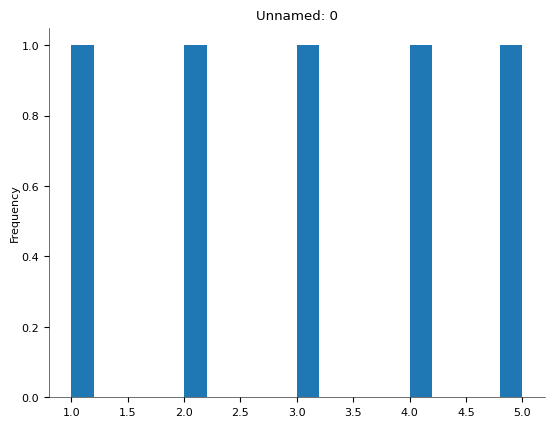

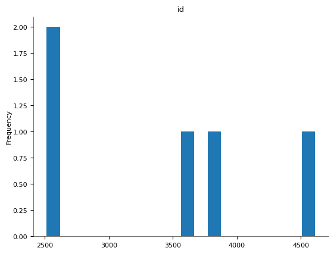

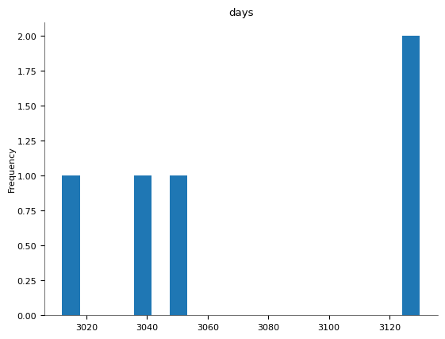

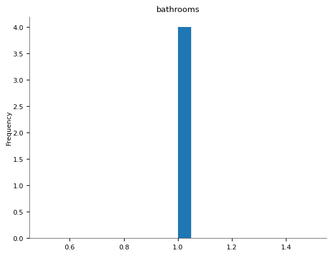

Categorical distributions

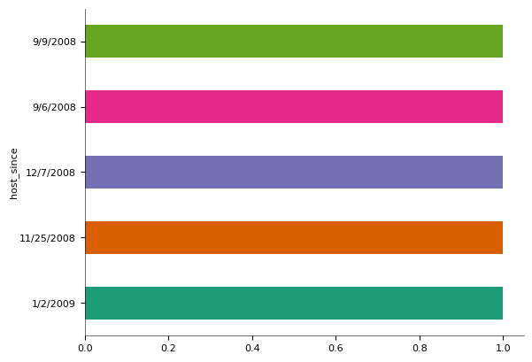

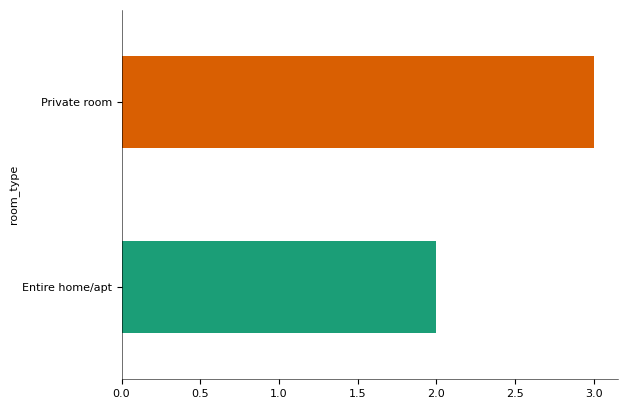

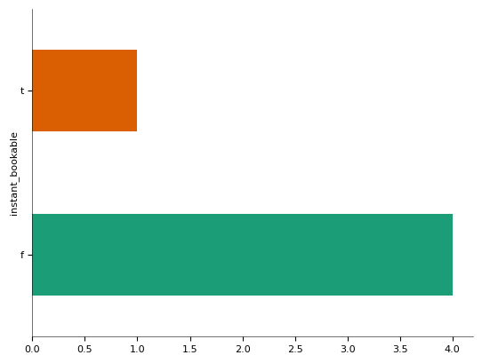

2-d distributions

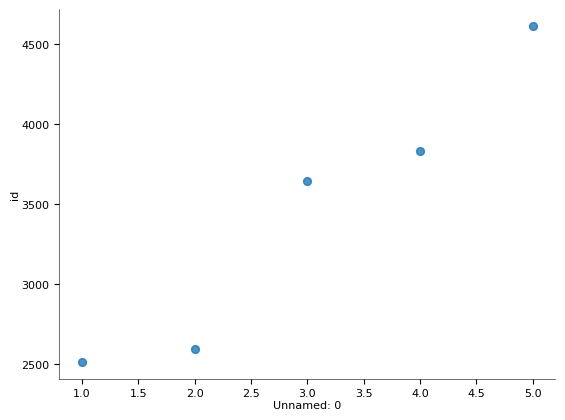

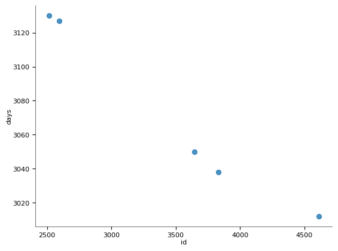

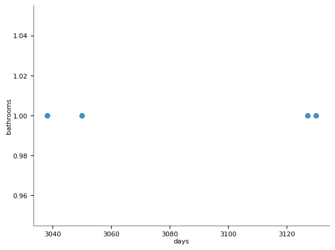

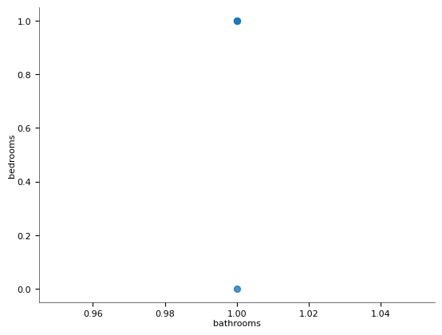

Time series

[figure not shown]

[13 more figures not shown]

```python
import pandas as pd


airbnb = pd.read_csv("/content/airbnb.csv")


airbnb.head()
```

```
<class 'pandas.core.frame.DataFrame'>
RangeIndex: 40628 entries, 0 to 40627
Data columns (total 14 columns):
 #   Column                     Non-Null Count  Dtype
---  ------                     --------------  -----
 0   Unnamed: 0                 40628 non-null  int64
 1   id                         40628 non-null  int64
 2   days                       40628 non-null  int64
 3   last_scraped               40628 non-null  object
 4   host_since                 40593 non-null  object
 5   room_type                  40628 non-null  object
 6   bathrooms                  40468 non-null  float64
 7   bedrooms                   40552 non-null  float64
 8   price                      40628 non-null  int64
 9   number_of_reviews          40628 non-null  int64
 10  review_scores_cleanliness  30433 non-null  float64
 11  review_scores_location     30374 non-null  float64
 12  review_scores_value        30372 non-null  float64
 13  instant_bookable           40628 non-null  object
dtypes: float64(5), int64(5), object(4)
memory usage: 4.3+ MB
```

|  | Unnamed: 0 | id | days | bathrooms | bedrooms | price | number_of_reviews | review_scores_cleanliness | review_scores_location | review_scores_value |
| --- | --- | --- | --- | --- | --- | --- | --- | --- | --- | --- |
| count | 40628.000000 | 4.062800e+04 | 40628.000000 | 40468.000000 | 40552.000000 | 40628.000000 | 40628.000000 | 30433.000000 | 30374.000000 | 30372.000000 |
| mean | 20314.500000 | 9.698889e+06 | 1102.368219 | 1.124592 | 1.147046 | 144.760732 | 15.904426 | 9.198370 | 9.413544 | 9.331522 |
| std | 11728.437705 | 5.460166e+06 | 1383.269358 | 0.385884 | 0.691746 | 210.657597 | 29.246009 | 1.119935 | 0.844949 | 0.902966 |
| min | 1.000000 | 2.515000e+03 | 1.000000 | 0.000000 | 0.000000 | 10.000000 | 0.000000 | 2.000000 | 2.000000 | 2.000000 |
| 25% | 10157.750000 | 4.889868e+06 | 542.000000 | 1.000000 | 1.000000 | 70.000000 | 1.000000 | 9.000000 | 9.000000 | 9.000000 |
| 50% | 20314.500000 | 9.862878e+06 | 996.000000 | 1.000000 | 1.000000 | 100.000000 | 4.000000 | 10.000000 | 10.000000 | 10.000000 |
| 75% | 30471.250000 | 1.466789e+07 | 1535.000000 | 1.000000 | 1.000000 | 170.000000 | 17.000000 | 10.000000 | 10.000000 | 10.000000 |
| max | 40628.000000 | 1.800967e+07 | 42828.000000 | 8.000000 | 10.000000 | 10000.000000 | 421.000000 | 10.000000 | 10.000000 | 10.000000 |

Distributions

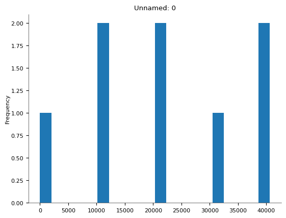

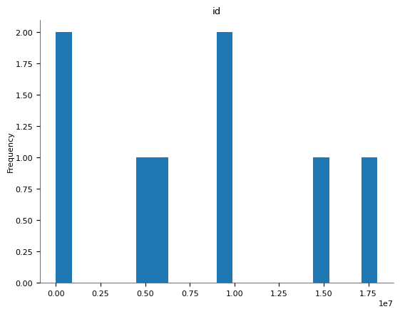

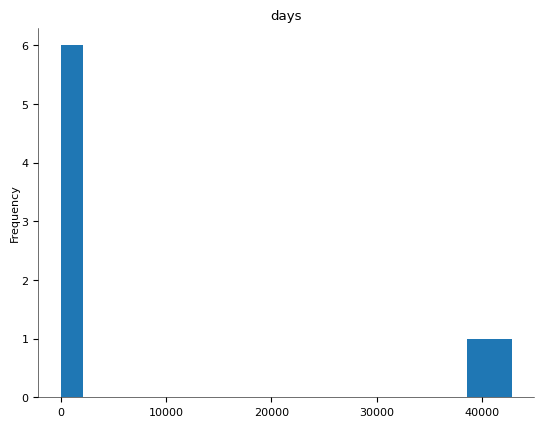

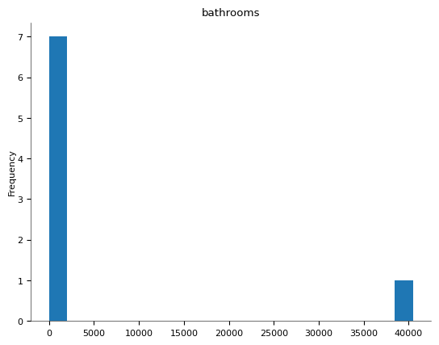

2-d distributions

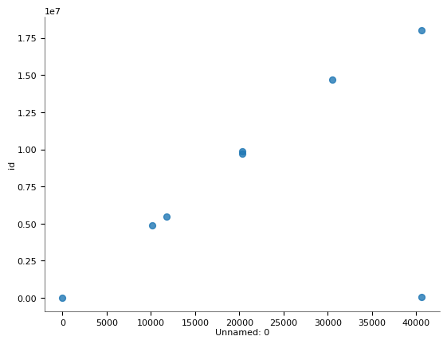

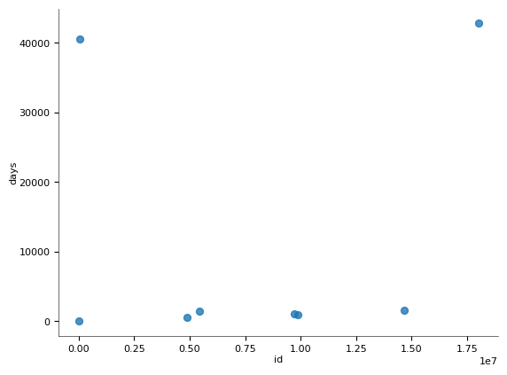

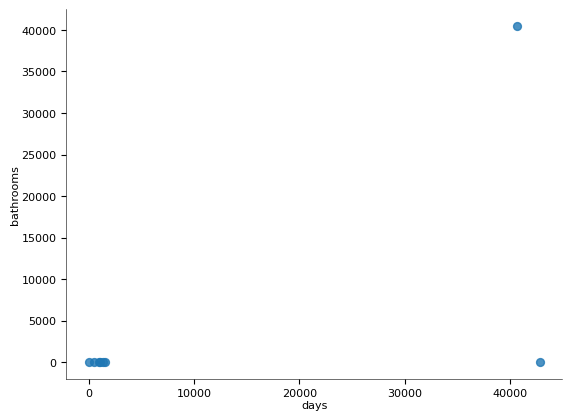

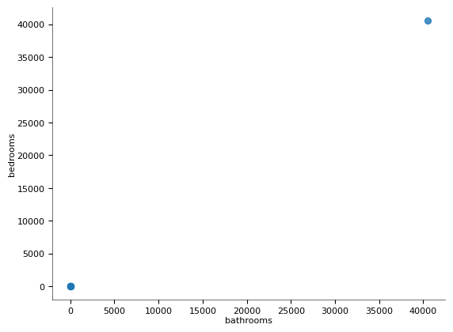

Values

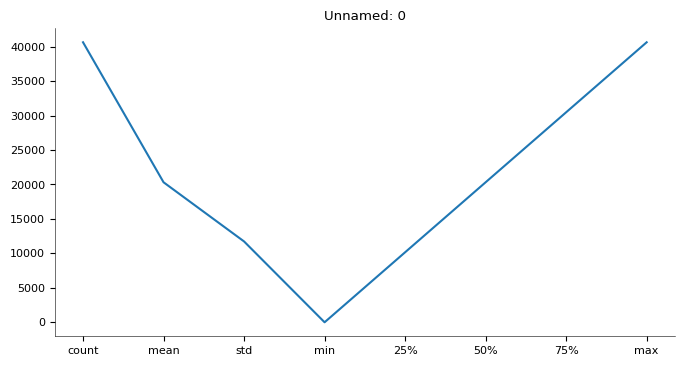

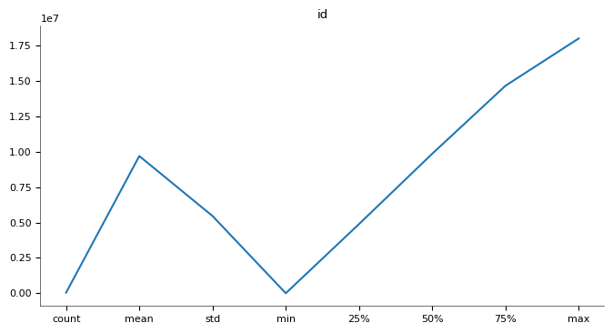

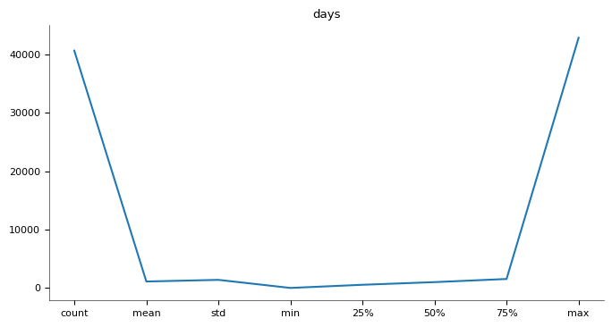

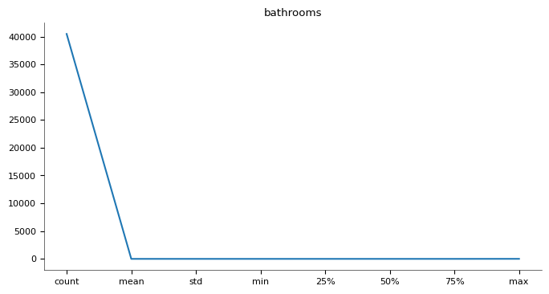

```python
airbnb.info()


airbnb.describe()
```